# Chapter 12 & 13

## Jae Wook Jung

### Mar. 27. 2020

```python
import numpy as np
import matplotlib.pyplot as plt
import pandas as pd
```

## Q1) Your day as chair of the Fed:

With the goal of stabilizing output, explain how and why you would change the interest rate in response to the following shocks using the IS-MP framewkr. Your answer should be numerical, i.e. I would change the real interest rate to 2.3%. Assume the following parameter values:

\begin{align*} \bar{a} = 0\\ \bar{r} = 2\%\\ \bar{b} = 1/2 \end{align*}

**(a)** Consumers become pessimistic about the state of the economy and future productivity growth and $\Delta \bar{a}_{C}=-.5$. Calculate this by hand and input your answer below.

0 = (-0.5) - (0.5*(Rt-2))

Rt = 1%

**(b)** Improvements in information technology increase productivity and therefore increase the marginal product of capital and $\Delta\bar{r}=1\%$. Calculate this by hand and input your answer below.

Rt = 3%

**(c)** A booming economy in Europe this year leads to an unexpected increase in the demand of U.S. goods and $\Delta \bar{a}_{EX} =1$. Calculate this by hand and input your answer below.

0 = 1 - 0.5*(Rt-2)

Rt = 4%

**(d)** Americans develop and infatuation with all things made in New Zealand and sharply increase their imports from that country and $\Delta \bar{a}_{IM} = 0.2$

```python
# 0 = -0.2 -0.5(Rt - 2)
Rt = 0.2/(-0.5) + 2
print(Rt, "%")
```

```
1.6 %
```

**(e)** A large earthquake destroys many houses and buildings on the West Coast, but "fortunately" results in little loss of life - *I'll let you decide what changed in this scenario and by how much.*

```python
print("bar_a got increased. Government is using a lot of money. ie. a = 2")
Rt = -2/(-0.5) + 2
print("the real interest rate becomes",Rt,"% to make output stabilized")
```

```
bar_a got increased. Government is using a lot of money. ie. a = 2
the real interest rate becomes 6.0 % to make output stabilized
```

**(f)** A housing bubble starts, so that housing prices fall by 20% and new home sales drop sharply - *I'll let you decide what changed in this scenario and the magnitudes of the change. Hint: see page 315 of your textbook*

```python
print("bar_a got decreased. Consumption, and investment shrink. ie. a = -2")
Rt = 2/(-0.5) + 2
print("the real interest rate becomes",Rt,"% to make output stabilized")
```

```
bar_a got decreased. Consumption, and investment shrink. ie. a = -2
the real interest rate becomes -2.0 % to make output stabilized
```

## Q2) Crowding out:

Consider a new monetary policy rule, where monetary policy depends only on short-run output: $$ R_t -\bar{r}= \bar{n}\tilde{Y}_{t}$$

AS : inf_t = inf_t1 + v*Yt_s + o

AD : Yt_s = a / (1+b*n)

IS : Yt_s = a - b*(Rt - r)

MP : Rt = n*Yt_s + r

**(a)** Assuming that $\bar{n}=1/2$, draw a new diagram where instead of the usual IS and MP curves, you plot the simplified version of the Taylor rule along with the IS curve. You might label this new curve MPR for “monetary policy rule.” How does your graph differ from the standard IS-MP diagram.

```
standard MP curve is a straight line which inflation is steady. But MPR is depending on short-run output, MPR has a slope
```

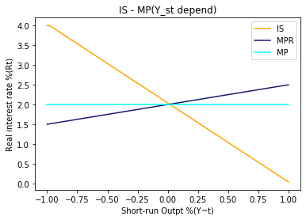

```python
a = 0
b = 0.5
r = 2
n = 0.5

i = 0

Y_st = np.linspace(-a - b*r, a + b*r, 101)
R_t = (((a - Y_st[i]) / b) + r)

for i in range(0, 100):
    R_t = np.append(R_t, ((a - Y_st[i]) / b) + r)

R_tm = n*Y_st + r

Rt = r
for i in range(0, 100):
    Rt = np.append(Rt, r)

print("standard MP curve is a straight line which inflation is steady. But MPR is depending on short-run output, MPR has a slope")
plt.plot(Y_st, R_t, "orange", label = "IS")
plt.plot(Y_st, R_tm, "midnightblue", label = "MPR")
plt.plot(Y_st, Rt, "aqua", label = "MP")
plt.title("IS - MP(Y_st depend)")
plt.xlabel("Short-run Outpt %(Y~t)")
plt.ylabel("Real interest rate %(Rt)")
plt.legend()
plt.show()
```

**(b)** Now consider the effect of a positive aggregate demand shock in the shape of a fiscal stimulus bill. Compare and contrast the effect of this shock on the economy in the standard IS-MP diagram versus the IS-MPR diagram. Why is the result different? Assume that $\bar{n}=1/2$ and that the IS curve follows its initial parameters (see the Preliminaries section above).

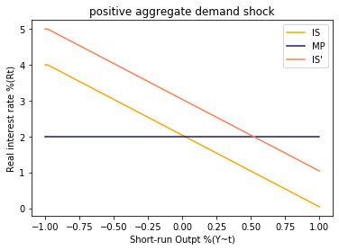

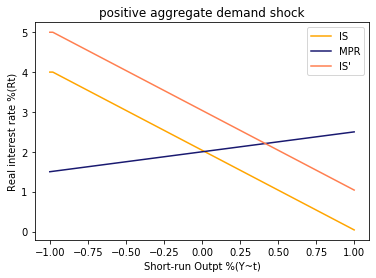

```python
a = 0
b = 0.5
r = 2
n = 0.5

i = 0

Y_st1 = np.linspace(-a - b*r, a + b*r, 101)
R_t1 = (((a - Y_st1[i]) / b) + r)

for i in range(0, 100):
    R_t1 = np.append(R_t1, ((a - Y_st1[i]) / b) + r)

Rt1 = r
for i in range(0, 100):
    Rt1 = np.append(Rt1, r)

a = 0.5
b = 0.5
r = 2
n = 0.5

i = 0

R_t2 = (((a - Y_st1[i]) / b) + r)

for i in range(0, 100):
    R_t2 = np.append(R_t2, ((a - Y_st1[i]) / b) + r)

plt.plot(Y_st1, R_t1, "orange", label = "IS")
plt.plot(Y_st1, Rt1, "midnightblue", label = "MP")
plt.plot(Y_st1, R_t2, "coral", label = "IS'")
plt.title("positive aggregate demand shock")
plt.xlabel("Short-run Outpt %(Y~t)")
plt.ylabel("Real interest rate %(Rt)")
plt.legend()
plt.show()
##############################3
a = 0
b = 0.5
r = 2
n = 0.5

i = 0

Y_st2 = np.linspace(-a - b*r, a + b*r, 101)
R_t4 = (((a - Y_st1[i]) / b) + r)

for i in range(0, 100):
    R_t4 = np.append(R_t4, ((a - Y_st2[i]) / b) + r)

Rt2 = n*Y_st2 + r

a = 0.5
b = 0.5
r = 2
n = 0.5

i = 0

R_t5 = (((a - Y_st2[i]) / b) + r)

for i in range(0, 100):
    R_t5 = np.append(R_t5, ((a - Y_st2[i]) / b) + r)

plt.plot(Y_st2, R_t4, "orange", label = "IS")
plt.plot(Y_st2, Rt2, "midnightblue", label = "MPR")
plt.plot(Y_st2, R_t5, "coral", label = "IS'")
plt.title("positive aggregate demand shock")
plt.xlabel("Short-run Outpt %(Y~t)")
plt.ylabel("Real interest rate %(Rt)")
plt.legend()
plt.show()
```

Because MPR has a slope depended on short-run output. The real interest rate is increasing so the short-run output is smaller than the steady interest rate of short-run output.

**(c)** Economists refer to the result in the IS-MPR diagram as “crowding out.” What gets crowded out and why?

Crowding out is a situation that the interest rate gets high because there is no much of money left in banks to lend. MPR: Rt = n*Y_st + r. As a government lends more money, aggregate demand shock increases becuase the government purchases increases. Then, we can see that the real interest rate in MPR increases naturally. So, MPR can be as a indicator for crowding out.

## Q3) Revisiting the effect of the booming European economy:

Reread the aggregate demand shock example (event #3) in Section 13.5 of your textbook. Suppose the parameters of the AS and AD curves take the following values: \begin{align*} \bar{a}=2\\ \bar{b}=1/2\\ \bar{m}=1\\ \bar{\nu}=1/2\\ \bar{\pi}=3%\\ \end{align*}

**a)** Assuming that the aggregate demand shock lasts 3 years, solve for the time paths of short-run output $\tilde{Y}_{t}$ and the inflation rate $\pi_{t}$ for 15 periods.

AS : inf = inf_1 + v*Yt_s + o

AD : inf = (a - Ys)/b*m + inf_s

```python
# Hint: you have to create an array for short-run output and the inflation rate starting
# at the parameter values stated above.
### I would use a loop to simulate how the economy evolves over time. Note: after three periods,
# change a to zero and continue the loop.

# making an array for 'a' is better
# a = [0]
# time = period length
# a = np.zeros(time)
# a[1:4] = 2
a = 2
b = 1/2
m = 1
v = 1/2
inf_s = 3
o = 0
i = 0

inf = [inf_s, (inf_s + v*a + v*b*m*inf_s + o) / (1 + v*b*m)]
Ys = [0, a - (b*m*(inf[0] - inf_s))]
time = [0, 1]

for i in range(2,4):
    time = np.append(time, i)
    inf = np.append(inf, (inf[i - 1] + v*a + v*b*m*inf_s + o) / (1 + v*b*m))
    Ys = np.append(Ys, a - (b * m * (inf[i] - inf_s)))

a = 0
for i in range(4, 15):
    time = np.append(time, i)
    inf = np.append(inf, (inf[i - 1] + v*a + v*b*m*inf_s + o) / (1 + v*b*m))
    Ys = np.append(Ys, a - (b * m * (inf[i] - inf_s)))
print(a)
print(time)
```

```
0
[ 0  1  2  3  4  5  6  7  8  9 10 11 12 13 14]
```

**b)** Plot the time series for short-run output $\tilde{Y}_{t}$ and the inflation rate $\pi_{t}$

```
inf: [3.         3.8        4.44       4.952      4.5616     4.24928
 3.999424   3.7995392  3.63963136 3.51170509 3.40936407 3.32749126
 3.26199301 3.2095944  3.16767552]
Ys: [ 0.          2.          1.28        1.024      -0.7808     -0.62464
 -0.499712   -0.3997696  -0.31981568 -0.25585254 -0.20468204 -0.16374563
 -0.1309965  -0.1047972  -0.08383776]
```

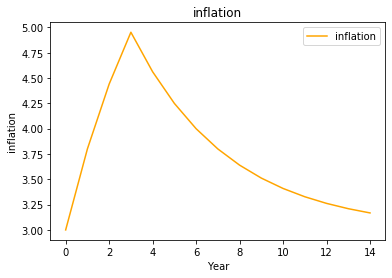

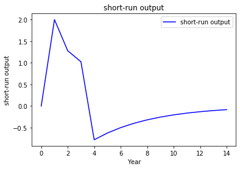

```python
print("inf:", inf)
print("Ys:", Ys)
plt.plot(time, inf, "orange", label = "inflation")
plt.title("inflation")
plt.xlabel("Year")
plt.ylabel("inflation")
plt.legend()
plt.show()
plt.plot(time, Ys, "blue", label = "short-run output")
plt.title("short-run output")
plt.xlabel("Year")
plt.ylabel("short-run output")
plt.legend()
plt.show()
```

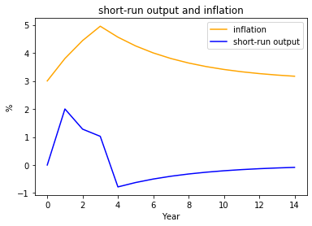

```python
plt.plot(time, inf, "orange", label = "inflation")
plt.plot(time, Ys, "blue", label = "short-run output")
plt.title("short-run output and inflation")
plt.xlabel("Year")
plt.ylabel("%")
plt.legend()
plt.show()
```

**c)** Assuming that $Y=100$ $P=100$ is the value of real output $Y_{t}$ and the price level $P_{t}$ for the 10 periods preceeding the AD shock, plot the time path of real output and price level before, during, and after the AD shock. You should have a total of 25 periods in your time series.

```
[3.         3.8        4.44       4.952      5.3616     5.68928
 5.951424   6.1611392  6.32891136 6.46312909 6.57050327 5.85640262
 5.28512209 4.82809767 4.46247814 4.16998251 3.93598601 3.74878881
 3.59903105 3.47922484 3.38337987 3.3067039  3.24536312 3.19629049
 3.15703239]
[100.         103.8        108.24       113.192      118.5536
 124.24288    130.194304   136.3554432  142.68435456 149.14748365
 155.71798692 161.57438953 166.85951163 171.6876093  176.15008744
 180.32006995 184.25605596 188.00484477 191.60387582 195.08310065
 198.46648052 201.77318442 205.01854753 208.21483803 211.37187042]
[100.         103.         108.09       112.6127     117.015081
 121.34473343 125.64043543 129.9339365  134.25138499 138.61447086
 143.04134044 147.54732902 150.54554758 153.91935296 157.62288472
 161.62033219 165.8839509  170.39247642 175.12985631 180.08423647
 185.24715115 190.61287575 196.17791007 201.94056582 207.90063755]
```

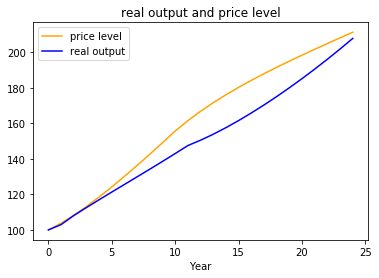

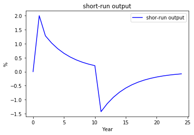

```python
Y0 = 100
P0 = 100

# y_growth_rate = 0.03
# y[i] = y[i - 1]*(1+y_growth_rate)
g = 0.03   #### growth rate
a = 2      ### aggregate demand
b = 1/2    #### reaction with firms invest
m = 1       ####### how the Fed reacts, how aggressively dealing with inflation
v = 1/2    #### react with the short-run output, phillips curve slope
inf_s = 3
o = 0     #### supply shock, inflation shock
i = 0

inf = [inf_s, (inf_s + v*a + v*b*m*inf_s + o) / (1 + v*b*m)]
Ys = [0, a - (b*m*(inf[0] - inf_s))]
time = [0,1]

for i in range(2,11):
    time = np.append(time, i)
    inf = np.append(inf, (inf[i - 1] + v*a + v*b*m*inf_s + o) / (1 + v*b*m))
    Ys = np.append(Ys, a - (b * m * (inf[i] - inf_s)))

a = 0
for i in range(11, 25):
    time = np.append(time, i)
    inf = np.append(inf, (inf[i - 1] + v*a + v*b*m*inf_s + o) / (1 + v*b*m))
    Ys = np.append(Ys, a - (b * m * (inf[i] - inf_s)))

Y = [Y0]
P = [P0]
i = 0

for i in range(0, 24):
    i += 1
    Y = np.append(Y, Y[i - 1]*(1 + g) + Ys[i - 1])
    P = np.append(P, P[i - 1] + inf[i])

print(inf)
print(P)
print(Y)
plt.plot(time, P, "orange", label = "price level")
plt.plot(time, Y, "blue", label = "real output")
plt.title("real output and price level")
plt.xlabel("Year")
# plt.ylabel("dollars")
plt.legend()
plt.show()

plt.plot(time, Ys, "blue", label = "shor-run output")
plt.title("short-run output")
plt.xlabel("Year")
plt.ylabel("%")
plt.legend()
plt.show()
```

```
[3.         3.8        4.44       4.952      5.3616     5.68928
 5.951424   6.1611392  6.32891136 6.46312909 6.57050327 5.85640262
 5.28512209 4.82809767 4.46247814 4.16998251 3.93598601 3.74878881
 3.59903105 3.47922484 3.38337987 3.3067039  3.24536312 3.19629049
 3.15703239]
[100.         103.8        108.24       113.192      118.5536
 124.24288    130.194304   136.3554432  142.68435456 149.14748365
 155.71798692 161.57438953 166.85951163 171.6876093  176.15008744
 180.32006995 184.25605596 188.00484477 191.60387582 195.08310065
 198.46648052 201.77318442 205.01854753 208.21483803 211.37187042]
[100.         100.         102.         103.28       104.304
 105.1232     105.77856    106.302848   106.7222784  107.05782272
 107.32625818 107.54100654 106.11280523 104.97024419 104.05619535
 103.32495628 102.73996502 102.27197202 101.89757761 101.59806209
 101.35844967 101.16675974 101.01340779 100.89072623 100.79258099]
```

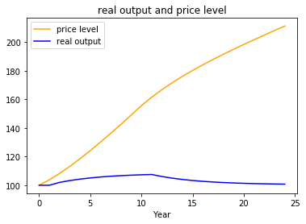

```python
#without growth rate

Y0 = 100
P0 = 100

a = 2      ### aggregate demand
b = 1/2    #### reaction with firms invest
m = 1       ####### how the Fed reacts, how aggressively dealing with inflation
v = 1/2    #### react with the short-run output, phillips curve slope
inf_s = 3
o = 0     #### supply shock, inflation shock
i = 0

inf = [inf_s, (inf_s + v*a + v*b*m*inf_s + o) / (1 + v*b*m)]
Ys = [0, a - (b*m*(inf[0] - inf_s))]
time = [0,1]

for i in range(2,11):
    time = np.append(time, i)
    inf = np.append(inf, (inf[i - 1] + v*a + v*b*m*inf_s + o) / (1 + v*b*m))
    Ys = np.append(Ys, a - (b * m * (inf[i] - inf_s)))

a = 0
for i in range(11, 25):
    time = np.append(time, i)
    inf = np.append(inf, (inf[i - 1] + v*a + v*b*m*inf_s + o) / (1 + v*b*m))
    Ys = np.append(Ys, a - (b * m * (inf[i] - inf_s)))

Y = [Y0]
P = [P0]
i = 0

for i in range(0, 24):
    i += 1
    Y = np.append(Y, Y[i - 1] + Ys[i - 1])
    P = np.append(P, P[i - 1] + inf[i])

print(inf)
print(P)
print(Y)
plt.plot(time, P, "orange", label = "price level")
plt.plot(time, Y, "blue", label = "real output")
plt.title("real output and price level")
plt.xlabel("Year")
# plt.ylabel("dollars")
plt.legend()
plt.show()
```

## Q4) The Taylor rule:

John Taylor of Stanford University proposed the following monetary policy rule: $$ R_t - \bar{r} = \bar{m}(\pi_{t}-\bar{\pi})+\bar{n}\tilde{Y}_{t} $$

That is, Taylor suggests that monetary policy should increase the real interest rate whenever output exceeds potential.

**a)** What is the economic justification for such a rule?

r = 2, m = 0.5, inf_s = 2

**b)** Combine this policy rule with the IS curve to get a new aggregate demand curve. How does it differ from the AD curve we considered in the chapter? Consider the response of short-run output to aggregate demand shocks and inflation shocks

AD : Ys = (a / (1+bn)) - (bm / (1 + bn)) * (inf - inf_s)

aggregate demand shocks will impact less than the original AD curve because 1 + bn > 1. So, the curve will shift less out.

inflation shocks will impact less than the original AD curve because 1 + bn > 1, So, the curve will shift less slope change.

**c)** Redo **Q3)** using this new AD curve. Assume that $\bar{n}=1/2$. Please describe the effect of a different monetary policy rule on business cycles.

```
[ 0  1  2  3  4  5  6  7  8  9 10 11 12 13 14]
[3.         3.72727273 4.38842975 4.98948159 4.80861963 4.64419966
 4.49472697 4.3588427  4.23531154 4.12301049 4.02091863 3.92810785
 3.84373441 3.76703128 3.69730116]
[ 0.          1.6         1.32231405  1.20210368 -0.36172393 -0.32883993
 -0.29894539 -0.27176854 -0.24706231 -0.2246021  -0.20418373 -0.18562157
 -0.16874688 -0.15340626 -0.13946023]
```

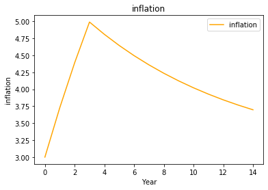

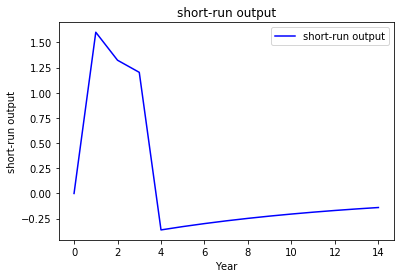

```python
# aggregate demand shock lasting for 3 periods

a = 2
b = 1/2
m = 1/2
v = 1/2
inf_s = 3
o = 0
n = 1/2
i = 0

inf = [inf_s, ((1 + b*n)/(1 + b*n + v*b*m))*(inf_s + o) + (1/(1 + b*n+v*b*m))*(v*a + v*b*m*inf_s)]
Ys = [0, (a - (b*m*(inf[0] - inf_s))) / (1 + b*n)]
time = [0,1]

for i in range(2,4):
    time = np.append(time, i)
    inf = np.append(inf, ((1 + b*n)/(1 + b*n + v*b*m))*(inf[i - 1] + o) + (1/(1 + b*n+v*b*m))*(v*a + v*b*m*inf_s))
    Ys = np.append(Ys, (a - (b*m*(inf[i] - inf_s))) / (1 + b*n))

a = 0
for i in range(4, 15):
    time = np.append(time, i)
    inf = np.append(inf, ((1 + b*n)/(1 + b*n + v*b*m))*(inf[i - 1] + o) + (1/(1 + b*n+v*b*m))*(v*a + v*b*m*inf_s))
    Ys = np.append(Ys, (a - (b*m*(inf[i] - inf_s))) / (1 + b*n))

print(time)
print(inf)
print(Ys)
plt.plot(time, inf, "orange", label = "inflation")
plt.title("inflation")
plt.xlabel("Year")
plt.ylabel("inflation")
plt.legend()
plt.show()
plt.plot(time, Ys, "blue", label = "short-run output")
plt.title("short-run output")
plt.xlabel("Year")
plt.ylabel("short-run output")
plt.legend()
plt.show()
```

```
[3.         3.72727273 4.38842975 4.98948159 5.53589236 6.03262942
 6.48420856 6.89473505 7.26794096 7.60721905 7.91565368 7.46877608
 7.06252371 6.69320337 6.35745761 6.05223419 5.77475835 5.52250759
 5.29318872 5.08471702 4.89519729 4.72290663 4.56627875 4.42388978
 4.29444525]
[ 0.          1.6         1.32231405  1.20210368  1.09282153  0.99347412
  0.90315829  0.82105299  0.74641181  0.67855619  0.61686926 -0.89375522
 -0.81250474 -0.73864067 -0.67149152 -0.61044684 -0.55495167 -0.50450152
 -0.45863774 -0.4169434  -0.37903946 -0.34458133 -0.31325575 -0.28477796
 -0.25888905]
[100.         103.72727273 108.11570248 113.10518407 118.64107643
 124.67370584 131.1579144  138.05264946 145.32059042 152.92780947
 160.84346315 168.31223923 175.37476294 182.06796631 188.42542392
 194.4776581  200.25241646 205.77492405 211.06811278 216.1528298
 221.04802709 225.77093372 230.33721247 234.76110224 239.0555475 ]
[ 0  1  2  3  4  5  6  7  8  9 10 11 12 13 14 15 16 17 18 19 20 21 22 23
 24]
```

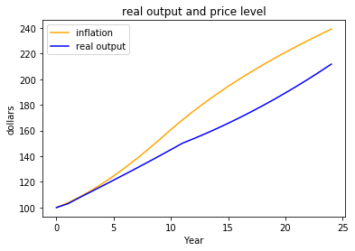

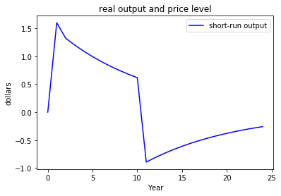

```python
# 3.c

Y0 = 100
P0 = 100

g = 0.03
a = 2
b = 1/2
m = 1/2
v = 1/2
inf_s = 3
o = 0
n = 1/2
i = 0


inf = [inf_s, ((1 + b*n)/(1 + b*n + v*b*m))*(inf_s + o) + (1/(1 + b*n+v*b*m))*(v*a + v*b*m*inf_s)]
Ys = [0, (a - (b*m*(inf[0] - inf_s))) / (1 + b*n)]
time = [0,1]

for i in range(2,11):
    time = np.append(time, i)
    inf = np.append(inf, ((1 + b*n)/(1 + b*n + v*b*m))*(inf[i - 1] + o) + (1/(1 + b*n+v*b*m))*(v*a + v*b*m*inf_s))
    Ys = np.append(Ys, (a - (b*m*(inf[i] - inf_s))) / (1 + b*n))

a = 0
for i in range(11, 25):
    time = np.append(time, i)
    inf = np.append(inf, ((1 + b*n)/(1 + b*n + v*b*m))*(inf[i - 1] + o) + (1/(1 + b*n+v*b*m))*(v*a + v*b*m*inf_s))
    Ys = np.append(Ys, (a - (b*m*(inf[i] - inf_s))) / (1 + b*n))

Y = [Y0]
P = [P0]

for i in range(0, 24):
    i += 1
    Y = np.append(Y, Y[i - 1]*(1 + g) + Ys[i - 1])
    P = np.append(P, P[i - 1] + inf[i])

print(inf)
print(Ys)
print(P)
print(time)
plt.plot(time, P, "orange", label = "inflation")
plt.plot(time, Y, "blue", label = "real output")
plt.title("real output and price level")
plt.xlabel("Year")
plt.ylabel("dollars")
plt.legend()
plt.show()
plt.plot(time, Ys, "blue", label = "short-run output")
plt.title("real output and price level")
plt.xlabel("Year")
plt.ylabel("dollars")
plt.legend()
plt.show()
```

```
[3.         3.72727273 4.38842975 4.98948159 5.53589236 6.03262942
 6.48420856 6.89473505 7.26794096 7.60721905 7.91565368 7.46877608
 7.06252371 6.69320337 6.35745761 6.05223419 5.77475835 5.52250759
 5.29318872 5.08471702 4.89519729 4.72290663 4.56627875 4.42388978
 4.29444525]
[ 0.          1.6         1.32231405  1.20210368  1.09282153  0.99347412
  0.90315829  0.82105299  0.74641181  0.67855619  0.61686926 -0.89375522
 -0.81250474 -0.73864067 -0.67149152 -0.61044684 -0.55495167 -0.50450152
 -0.45863774 -0.4169434  -0.37903946 -0.34458133 -0.31325575 -0.28477796
 -0.25888905]
[100.         103.72727273 108.11570248 113.10518407 118.64107643
 124.67370584 131.1579144  138.05264946 145.32059042 152.92780947
 160.84346315 168.31223923 175.37476294 182.06796631 188.42542392
 194.4776581  200.25241646 205.77492405 211.06811278 216.1528298
 221.04802709 225.77093372 230.33721247 234.76110224 239.0555475 ]
[ 0  1  2  3  4  5  6  7  8  9 10 11 12 13 14 15 16 17 18 19 20 21 22 23
 24]
```

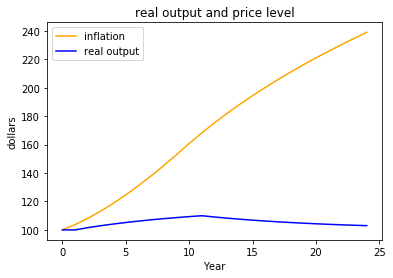

```python
# without growth rate

Y0 = 100
P0 = 100

a = 2
b = 1/2
m = 1/2
v = 1/2
inf_s = 3
o = 0
n = 1/2
i = 0


inf = [inf_s, ((1 + b*n)/(1 + b*n + v*b*m))*(inf_s + o) + (1/(1 + b*n+v*b*m))*(v*a + v*b*m*inf_s)]
Ys = [0, (a - (b*m*(inf[0] - inf_s))) / (1 + b*n)]
time = [0,1]

for i in range(2,11):
    time = np.append(time, i)
    inf = np.append(inf, ((1 + b*n)/(1 + b*n + v*b*m))*(inf[i - 1] + o) + (1/(1 + b*n+v*b*m))*(v*a + v*b*m*inf_s))
    Ys = np.append(Ys, (a - (b*m*(inf[i] - inf_s))) / (1 + b*n))

a = 0
for i in range(11, 25):
    time = np.append(time, i)
    inf = np.append(inf, ((1 + b*n)/(1 + b*n + v*b*m))*(inf[i - 1] + o) + (1/(1 + b*n+v*b*m))*(v*a + v*b*m*inf_s))
    Ys = np.append(Ys, (a - (b*m*(inf[i] - inf_s))) / (1 + b*n))

Y = [Y0]
P = [P0]

for i in range(0, 24):
    i += 1
    Y = np.append(Y, Y[i - 1] + Ys[i - 1])
    P = np.append(P, P[i - 1] + inf[i])

print(inf)
print(Ys)
print(P)
print(time)
plt.plot(time, P, "orange", label = "inflation")
plt.plot(time, Y, "blue", label = "real output")
plt.title("real output and price level")
plt.xlabel("Year")
plt.ylabel("dollars")
plt.legend()
plt.show()
```

A economy had a boom for 10 years from the period 1 (AD curve shifts out). If the real output was at potential at 100 level, the real output is over the potential level for 10 years. But because the inflation which is related to the real interest rate is increasing too, the economy is going back to the potential level with the higer inflation (real interest rate). The economic boom overs after period 10, and the economy is suddenly in a recession. And then the inflation goes down so as the real interest rate. And the economy is coming back to the initial place where it was in a steady state.

### homework from the class

```
inf: [2.         6.44444444 5.95061728 5.51165981 5.12147538 4.77464479
 4.46635092 4.19231193 3.94872172 3.73219708 3.53973074 3.36864955
 3.21657737 3.08140211 2.96124632]
Ys: [ 0.         -1.11111111 -0.98765432 -0.87791495 -0.78036885 -0.6936612
 -0.61658773 -0.54807798 -0.48718043 -0.43304927 -0.38493268 -0.34216239
 -0.30414434 -0.27035053 -0.24031158]
[ 0  1  2  3  4  5  6  7  8  9 10 11 12 13 14]
```

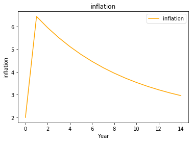

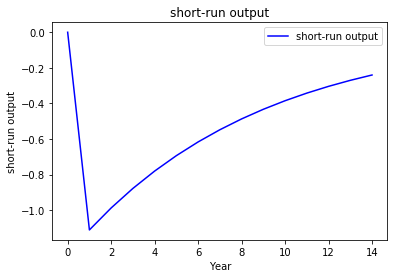

```python
a = 0
b = 1/2
m = 1/2
v = 1/2
inf_s = 2
o = 5
i = 0

inf = [inf_s, (inf_s + v*a + v*b*m*inf_s + o) / (1 + v*b*m)]
Ys = [0, a - (b*m*(inf[1] - inf_s))]
time = [0, 1]

o = 0
for i in range(2,4):
    time = np.append(time, i)
    inf = np.append(inf, (inf[i - 1] + v*a + v*b*m*inf_s + o) / (1 + v*b*m))
    Ys = np.append(Ys, a - (b * m * (inf[i] - inf_s)))

for i in range(4, 15):
    time = np.append(time, i)
    inf = np.append(inf, (inf[i - 1] + v*a + v*b*m*inf_s + o) / (1 + v*b*m))
    Ys = np.append(Ys, a - (b * m * (inf[i] - inf_s)))

print("inf:", inf)
print("Ys:", Ys)
print(time)
plt.plot(time, inf, "orange", label = "inflation")
plt.title("inflation")
plt.xlabel("Year")
plt.ylabel("inflation")
plt.legend()
plt.show()
plt.plot(time, Ys, "blue", label = "short-run output")
plt.title("short-run output")
plt.xlabel("Year")
plt.ylabel("short-run output")
plt.legend()
plt.show()
```

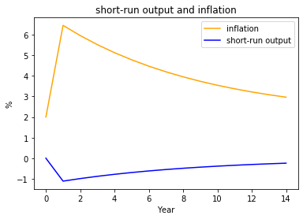

```python
plt.plot(time, inf, "orange", label = "inflation")
plt.plot(time, Ys, "blue", label = "short-run output")
plt.title("short-run output and inflation")
plt.xlabel("Year")
plt.ylabel("%")
plt.legend()
plt.show()
```